# Data_Wrangling

Fabio Damacena

04/12/2021

# Dataset Champions League

Vamos exercitar manipulação de dados com R. Para tanto, utilizaremos o pacote dplyr, que está contido no tidyverse. dplyr: contém muitas funções comuns na manipulação de dados.

Para o exercício, utilizaremos o dataset com os resultados dos jogos da temporada 20-21 da UEFA Champions League. Fonte: https://www.kaggle.com/datasets, enviado por Marco Carujo

## Importando arquivos

```r
library(tidyverse)
jogos <- read.csv("(5.2) Champions League 2020-2021.csv")
```

## Visualizando os dados carregados

### view

Mostra a base de dados completa em uma nova aba (no presente exemplo, apenas as 9 primeiras colunas)

```r
View(jogos[,1:9]) # não usar quando o dataset for muito grande
```

### head

Mostra as 5 primeiras observações da base de dados

```r
head(jogos[1:9], n=5)
```

```
##                      stage         date  pens pens_home_score pens_away_score
## 1                   Final   29.05.2021  False           False           False
## 2  Semi-finals second leg   05.05.2021  False           False           False
## 3  Semi-finals second leg   04.05.2021  False           False           False
## 4   Semi-finals first leg   28.04.2021  False           False           False
## 5   Semi-finals first leg   27.04.2021  False           False           False
##      team_name_home    team_name_away team_home_score team_away_score
## 1  Manchester City           Chelsea                0               1
## 2          Chelsea       Real Madrid                2               0
## 3  Manchester City               PSG                2               0
## 4              PSG   Manchester City                1               2
## 5      Real Madrid           Chelsea                1               1
```

### str

Mostra a estrutura da base de dados

```r
str(jogos[1:9])
```

```
## 'data.frame':    125 obs. of  9 variables:
##  $ stage          : chr  " Final " " Semi-finals second leg " " Semi-finals second leg " " Semi-finals first leg " ...
##  $ date           : chr  " 29.05.2021 " " 05.05.2021 " " 04.05.2021 " " 28.04.2021 " ...
##  $ pens           : chr  "False" "False" "False" "False" ...
##  $ pens_home_score: chr  "False" "False" "False" "False" ...
##  $ pens_away_score: chr  "False" "False" "False" "False" ...
##  $ team_name_home : chr  " Manchester City " " Chelsea " " Manchester City " " PSG " ...
##  $ team_name_away : chr  " Chelsea " " Real Madrid " " PSG " " Manchester City " ...
##  $ team_home_score: int  0 2 2 1 1 0 1 0 0 0 ...
##  $ team_away_score: int  1 0 0 2 1 0 2 1 1 2 ...
```

### glimpse

Outra alternativa para ver a estrutura da base de dados

```r
glimpse(jogos[1:9])
```

```
## Rows: 125
## Columns: 9
## $ stage           <chr> " Final ", " Semi-finals second leg ", " Semi-finals s~
## $ date            <chr> " 29.05.2021 ", " 05.05.2021 ", " 04.05.2021 ", " 28.0~
## $ pens            <chr> "False", "False", "False", "False", "False", "False", ~
## $ pens_home_score <chr> "False", "False", "False", "False", "False", "False", ~
## $ pens_away_score <chr> "False", "False", "False", "False", "False", "False", ~
## $ team_name_home  <chr> " Manchester City ", " Chelsea ", " Manchester City ",~
## $ team_name_away  <chr> " Chelsea ", " Real Madrid ", " PSG ", " Manchester Ci~
## $ team_home_score <int> 0, 2, 2, 1, 1, 0, 1, 0, 0, 0, 2, 3, 2, 2, 2, 2, 3, 1, ~
## $ team_away_score <int> 1, 0, 0, 2, 1, 0, 2, 1, 1, 2, 3, 1, 1, 0, 1, 0, 1, 1, ~
```

### print

Apresenta uma variável da base de dados no console

```r
print(jogos$location)
```

```
##   [1] " EstÃ¡dio Do DragÃ£o "
##   [2] " Stamford Bridge "
##   [3] " Etihad Stadium "
##   [4] " Parc des Princes "
##   [5] " Alfredo Di StÃ©fano "
##   [6] " Anfield "
##   [7] " SIGNAL IDUNA PARK "
##   [8] " Parc des Princes "
##   [9] " RamÃ³n SÃ¡nchez-PizjuÃ¡n "
##  [10] " RamÃ³n SÃ¡nchez-PizjuÃ¡n "
##  [11] " Allianz Arena "
##  [12] " Alfredo Di StÃ©fano "
##  [13] " Etihad Stadium "
##  [14] " Stamford Bridge "
##  [15] " Allianz Arena "
```

[output cut: 110 more lines]

### dim

As dimensões do dataset: linhas e colunas, respectivamente

```r
dim(jogos)
```

```
## [1] 125  24
```

### names

Para ver os nomes das variáveis

```r
names(jogos)
```

```
##  [1] "stage"                    "date"
##  [3] "pens"                     "pens_home_score"
##  [5] "pens_away_score"          "team_name_home"
##  [7] "team_name_away"           "team_home_score"
##  [9] "team_away_score"          "possession_home"
## [11] "possession_away"          "total_shots_home"
## [13] "total_shots_away"         "shots_on_target_home"
## [15] "shots_on_target_away"     "duels_won_home"
## [17] "duels_won_away"           "prediction_team_home_win"
## [19] "prediction_draw"          "prediction_team_away_win"
## [21] "location"                 "events_list"
## [23] "lineup_home"              "lineup_away"
```

## Função rename

Serve para alterar o nome das variáveis

```r
jogos = jogos %>% rename(fase = stage,
                 data = date,
                 mandante = team_name_home,
                 visitante = team_name_away)
head(jogos[1:9], n = 5)
```

```
##                       fase         data  pens pens_home_score pens_away_score
## 1                   Final   29.05.2021  False           False           False
## 2  Semi-finals second leg   05.05.2021  False           False           False
## 3  Semi-finals second leg   04.05.2021  False           False           False
## 4   Semi-finals first leg   28.04.2021  False           False           False
## 5   Semi-finals first leg   27.04.2021  False           False           False
##            mandante         visitante team_home_score team_away_score
## 1  Manchester City           Chelsea                0               1
## 2          Chelsea       Real Madrid                2               0
## 3  Manchester City               PSG                2               0
## 4              PSG   Manchester City                1               2
## 5      Real Madrid           Chelsea                1               1
```

## Função mutate

Função “mutate”: apresenta duas utilidades principais

- Inclui variáveis no dataset, mantendo as existentes
- Transforma o conteúdo das variáveis

Uma variável que não consta na lista é o time vencedor do jogo. Vamos criar usando o mutate e a função case_when para definir a fórmula. O case_when funciona como um “se -> então”

```r
jogos <- jogos %>% mutate(time_vencedor = case_when(
  c(jogos$team_home_score-jogos$team_away_score)==0 ~ "empate",
  c(jogos$team_home_score-jogos$team_away_score)>0 ~ "mandante",
  c(jogos$team_home_score-jogos$team_away_score)<0 ~ "visitante")) %>%
  relocate(time_vencedor, .after = team_away_score)
head(jogos[1:10], n = 5)
```

```
##                       fase         data  pens pens_home_score pens_away_score
## 1                   Final   29.05.2021  False           False           False
## 2  Semi-finals second leg   05.05.2021  False           False           False
## 3  Semi-finals second leg   04.05.2021  False           False           False
## 4   Semi-finals first leg   28.04.2021  False           False           False
## 5   Semi-finals first leg   27.04.2021  False           False           False
##            mandante         visitante team_home_score team_away_score
## 1  Manchester City           Chelsea                0               1
## 2          Chelsea       Real Madrid                2               0
## 3  Manchester City               PSG                2               0
## 4              PSG   Manchester City                1               2
## 5      Real Madrid           Chelsea                1               1
##   time_vencedor
## 1     visitante
## 2      mandante
## 3      mandante
## 4     visitante
## 5        empate
```

Vamos gerar um gráfico para visualizar melhor a informação resultante

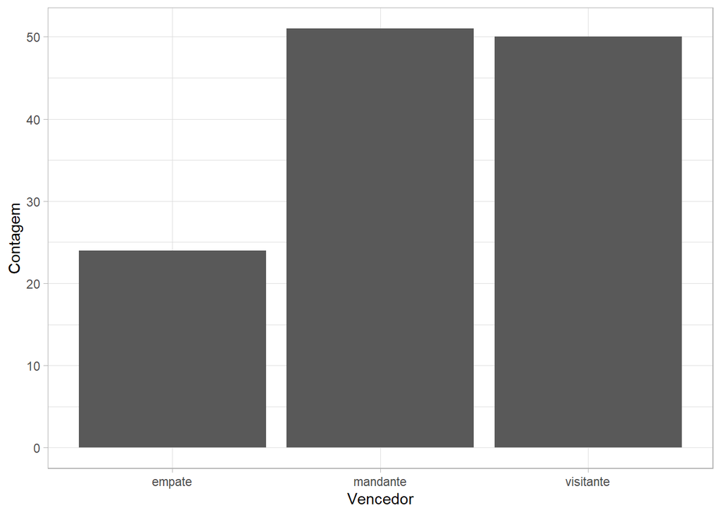

```r
ggplot(jogos) +
  geom_bar(aes(x = time_vencedor)) +
  labs(x = "Vencedor",
       y = "Contagem") +
  theme_light()
```

Vamos analisar o gráfico de acordo com as fases da competição:

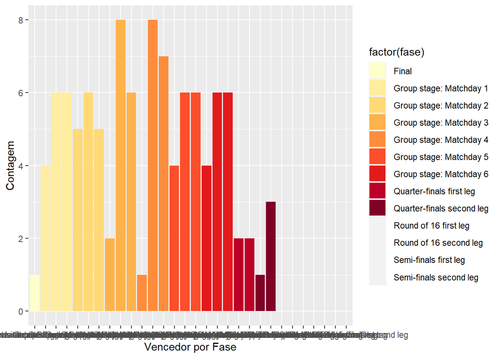

```r
ggplot(jogos) +
  geom_bar(aes(x = interaction(time_vencedor, fase), fill=factor(fase))) +
  labs(x = "Vencedor por Fase",
       y = "Contagem") +
  scale_fill_brewer(palette=18)
```

Uma informação interessante seria identificar os jogadores que fizeram os gols Esta informação está na variável “events_list” que é uma string mais complexa Precisamos retirar a informação específica, então vamos procurar um padrão A informação que queremos está sempre após – ‘Goal’, ‘action_player_1’: ’ –

```r
jogos[1, 23] # dados da variável event_list da linha 1
```

```
## [1] "[{'event_team': 'home', 'event_time': \" 34' \", 'event_type': 'Yellow card', 'action_player_1': ' Ilkay GÃ¼ndogan '}, {'event_team': 'away', 'event_time': \" 39' \", 'event_type': 'Substitution', 'action_player_1': ' Andreas Christensen ', 'action_player_2': ' Thiago Silva '}, {'event_team'…
```

```r
extrai_gol <- str_extract_all(jogos$events_list,
                     "'Goal', 'action_player_1': '\\w*(.*?)\\w*\\'",
                     simplify = TRUE)
```

Acima, utilizamos regex (regular expression), úteis para trabalhar em strings O str_extract_all pede para extrair em todas as ocorrências do padrão

Pedimos para extrair qualquer palavra () contida entre as extremidades: Extremidade 1: ‘Goal’, ‘action_player_1’: ’ Extremidade 2: ’ (só o apóstrofo) A seguir, apenas faremos uma limpeza no texto

```r
gol <- gsub("'Goal', 'action_player_1': ", "", extrai_gol)
gol_jogador <- gsub("'", "", gol)
```

```r
head(extrai_gol, n = 5)
```

```
##      [,1]
## [1,] "'Goal', 'action_player_1': ' Kai Havertz '"
## [2,] "'Goal', 'action_player_1': ' Timo Werner '"
## [3,] "'Goal', 'action_player_1': ' Riyad Mahrez '"
## [4,] "'Goal', 'action_player_1': ' Marquinhos '"
## [5,] "'Goal', 'action_player_1': ' Christian Pulisic '"
##      [,2]
## [1,] ""
## [2,] "'Goal', 'action_player_1': ' Mason Mount '"
## [3,] "'Goal', 'action_player_1': ' Riyad Mahrez '"
## [4,] "'Goal', 'action_player_1': ' Kevin De Bruyne '"
## [5,] "'Goal', 'action_player_1': ' Karim Benzema '"
##      [,3]                                          [,4] [,5] [,6] [,7]
## [1,] ""                                            ""   ""   ""   ""
## [2,] ""                                            ""   ""   ""   ""
## [3,] ""                                            ""   ""   ""   ""
## [4,] "'Goal', 'action_player_1': ' Riyad Mahrez '" ""   ""   ""   ""
## [5,] ""                                            ""   ""   ""   ""
```

```r
head(gol, n = 5)
```

```
##      [,1]                    [,2]                  [,3]               [,4] [,5]
## [1,] "' Kai Havertz '"       ""                    ""                 ""   ""
## [2,] "' Timo Werner '"       "' Mason Mount '"     ""                 ""   ""
## [3,] "' Riyad Mahrez '"      "' Riyad Mahrez '"    ""                 ""   ""
## [4,] "' Marquinhos '"        "' Kevin De Bruyne '" "' Riyad Mahrez '" ""   ""
## [5,] "' Christian Pulisic '" "' Karim Benzema '"   ""                 ""   ""
##      [,6] [,7]
## [1,] ""   ""
## [2,] ""   ""
## [3,] ""   ""
## [4,] ""   ""
## [5,] ""   ""
```

```r
head(gol_jogador, n = 5)
```

```
##      [,1]                  [,2]                [,3]             [,4] [,5] [,6]
## [1,] " Kai Havertz "       ""                  ""               ""   ""   ""
## [2,] " Timo Werner "       " Mason Mount "     ""               ""   ""   ""
## [3,] " Riyad Mahrez "      " Riyad Mahrez "    ""               ""   ""   ""
## [4,] " Marquinhos "        " Kevin De Bruyne " " Riyad Mahrez " ""   ""   ""
## [5,] " Christian Pulisic " " Karim Benzema "   ""               ""   ""   ""
##      [,7]
## [1,] ""
## [2,] ""
## [3,] ""
## [4,] ""
## [5,] ""
```

O mesmo critério vamos usar para extrair os gols de pênalti

```r
extrai_penalti <- str_extract_all(jogos$events_list,
              "'event_type': 'Penalty', 'action_player_1': '\\w*(.*?)\\w*\\'",
              simplify = TRUE)
extrai_penalti <- gsub("'event_type': 'Penalty', 'action_player_1': ", "", extrai_penalti)
extrai_penalti <- gsub("'", "", extrai_penalti)
```

Por fim, podemos pedir uma tabela de frequências dos gols

```r
sort(table(cbind(gol_jogador, extrai_penalti)), decreasing = T)
```

```
##
##                               Erling Haaland          Kylian Mbappe
##                    772                     10                      8
##         Alvaro Morata          Karim Benzema        Marcus Rashford
##                      6                      6                      6
##         Mohamed Salah                 Neymar         Olivier Giroud
##                      6                      6                      6
##     Youssef En-Nesyri          Alassane Plea          Ciro Immobile
##                      6                      5                      5
##          Lionel Messi     Robert Lewandowski        Sergio Oliveira
##                      5                      5                      5
##       Bruno Fernandes      Cristiano Ronaldo             Diogo Jota
##                      4                      4                      4
##    Eric Choupo-Moting        Federico Chiesa          Ferran Torres
##                      4                      4                      4
##       MÃ«rgim Berisha           Riyad Mahrez          Romelu Lukaku
##                      4                      4                      4
##           Timo Werner         Ä°rfan Kahveci        Anton Miranchuk
##                      4                      3                      3
##          Duvan Zapata           Hans Vanaken        Ilkay GÃ¼ndogan
##                      3                      3                      3
##          JoÃ£o FÃ©lix        JoaquÃn Correa           Jose Tasende
##                      3                      3                      3
##       Kevin De Bruyne         Kingsley Coman             Leroy Sane
##                      3                      3                      3
##           Luis Muriel             Marquinhos     Martin Braithwaite
##                      3                      3                      3
##            Moise Kean        Ousmane Dembele           Philip Foden
##                      3                      3                      3
##            Sadio Mane        Vinicius Junior       Alexander Scholz
##                      3                      3                      2
##       Anthony Martial      Antoine Griezmann     Callum Hudson-Odoi
##                      2                      2                      2
##  Charles De Ketelaere      Christian Pulisic          Dimitri Payet
##                      2                      2                      2
##    Dominik Szoboszlai            Dusan Tadic            Franck Boli
##                      2                      2                      2
##         Gabriel Jesus           Hakim Ziyech           Ivan Rakitic
##                      2                      2                      2
##          Jadon Sancho            Lars Stindl          Leon Goretzka
```

[output cut: 68 more lines]

```
##                      1                      1                      1
##       Raheem Sterling      Raphael Guerreiro           Remy Cabella
##                      1                      1                      1
##          Robin Gosens                Rodrygo            Ruud Vormer
##                      1                      1                      1
##      Ryan Gravenberch     SebastiÃ¡n Driussi          SergiÃ±o Dest
##                      1                      1                      1
##                  Suso          Tammy Abraham                  TetÃª
##                      1                      1                      1
##        Thorgan Hazard           Tokmac Nguen      Vitali Lisakovich
##                      1                      1                      1
##             Wanderson        Weston McKennie       Yannick Carrasco
##                      1                      1                      1
##        Yussuf Poulsen           Zaidu Sanusi       Zlatko Junuzovic
##                      1                      1                      1
```

## Função recode

Em conjunto com o mutate, também pode ser utilizada a função “recode”. Serve para, por exemplo, trocar um texto por outro texto e criar uma variável

```r
jogos = mutate(jogos,
                 exemplo_recode = recode(pens,
                                   "False" = "falso",
                                   "True" = "verdadeiro"))%>%
  relocate(exemplo_recode, .after = team_away_score)
head(jogos[1:10], n = 5)
```

```
##                       fase         data  pens pens_home_score pens_away_score
## 1                   Final   29.05.2021  False           False           False
## 2  Semi-finals second leg   05.05.2021  False           False           False
## 3  Semi-finals second leg   04.05.2021  False           False           False
## 4   Semi-finals first leg   28.04.2021  False           False           False
## 5   Semi-finals first leg   27.04.2021  False           False           False
##            mandante         visitante team_home_score team_away_score
## 1  Manchester City           Chelsea                0               1
## 2          Chelsea       Real Madrid                2               0
## 3  Manchester City               PSG                2               0
## 4              PSG   Manchester City                1               2
## 5      Real Madrid           Chelsea                1               1
##   exemplo_recode
## 1          falso
## 2          falso
## 3          falso
## 4          falso
## 5          falso
```

## Função transmute

Inclui variáveis no dataset, excluindo as existentes. Depois de informar o dataset, informe as variáveis mantidas e adicionadas:

```r
jogos_exclui = transmute(jogos,
                   fase, data)
head(jogos_exclui, n = 5)
```

```
##                       fase         data
## 1                   Final   29.05.2021
## 2  Semi-finals second leg   05.05.2021
## 3  Semi-finals second leg   04.05.2021
## 4   Semi-finals first leg   28.04.2021
## 5   Semi-finals first leg   27.04.2021
```

## Função select

Tem a finalidade principal de extrair variáveis selecionadas. Também pode ser utilizada para reposicionar as variáveis no dataset

```r
jogos = select(jogos,
                fase:location)
head(jogos, n = 5)
```

```
##                       fase         data  pens pens_home_score pens_away_score
## 1                   Final   29.05.2021  False           False           False
## 2  Semi-finals second leg   05.05.2021  False           False           False
## 3  Semi-finals second leg   04.05.2021  False           False           False
## 4   Semi-finals first leg   28.04.2021  False           False           False
## 5   Semi-finals first leg   27.04.2021  False           False           False
##            mandante         visitante team_home_score team_away_score
## 1  Manchester City           Chelsea                0               1
## 2          Chelsea       Real Madrid                2               0
## 3  Manchester City               PSG                2               0
## 4              PSG   Manchester City                1               2
## 5      Real Madrid           Chelsea                1               1
##   exemplo_recode time_vencedor possession_home possession_away total_shots_home
## 1          falso     visitante             61%            39%                 7
## 2          falso      mandante             32%            68%                15
```

[output cut: 21 more lines]

```r
jogos = jogos %>% select(fase, data, time_vencedor, everything())
head(jogos[1:10], n = 5)
```

```
##                       fase         data time_vencedor  pens pens_home_score
## 1                   Final   29.05.2021      visitante False           False
## 2  Semi-finals second leg   05.05.2021       mandante False           False
## 3  Semi-finals second leg   04.05.2021       mandante False           False
## 4   Semi-finals first leg   28.04.2021      visitante False           False
## 5   Semi-finals first leg   27.04.2021         empate False           False
##   pens_away_score          mandante         visitante team_home_score
## 1           False  Manchester City           Chelsea                0
## 2           False          Chelsea       Real Madrid                2
## 3           False  Manchester City               PSG                2
## 4           False              PSG   Manchester City                1
## 5           False      Real Madrid           Chelsea                1
##   team_away_score
## 1               1
## 2               0
## 3               0
## 4               2
## 5               1
```

## Função summarise

função que resume o dataset, podendo criar outros

```r
estatisticas_mandante = summarise(jogos,
                         mandante = n(),
                         media_gols = mean(team_home_score),
                         maximo = max(team_home_score))
estatisticas_mandante
```

```
##   mandante media_gols maximo
## 1      125      1.464      5
```

## Função group_by

Pode ser utilizada para criar informações mais específicas sobre o dataset. Para isto, o “summarise” é utilizado em conjunto com a função “group by”. Serve para agrupar as informações do dataset por determinado critério.

```r
times = group_by(jogos, mandante)
```

```r
estatisticas_times = times %>% summarise(media = mean(team_home_score),
                                         maximo = max(team_home_score))
estatisticas_times
```

```
## # A tibble: 32 x 3
##    mandante                   media maximo
##    <chr>                      <dbl>  <int>
##  1 " Ä°stanbul BaÅŸakÅŸehir "  1.67      3
##  2 " Ajax "                    1         3
##  3 " Atalanta "                0.75      2
##  4 " AtlÃ©tico Madrid "        1         3
##  5 " B. Mâ€˜Gladbach "         2         4
##  6 " Barcelona "               2         5
##  7 " Bayern Munich "           2.6       4
##  8 " Borussia Dortmund "       1.8       3
##  9 " Chelsea "                 1.33      3
## 10 " Club Brugge "             1.33      3
## # ... with 22 more rows
```

## Função filter

Filter: tem o objetivo de gerar subconjuntos do dataset. São especificados os critérios e as linhas que os atenderem serão filtradas. Os principais operadores lógicos são: ==: igual !=: diferente “> e <: maior e menor (podem conter o igual >= e <=) &: indica”E” |: indica “OU””

```r
mandante_fez_gol = filter(jogos, team_home_score > 0)
head(mandante_fez_gol[1:10])
```

```
##                          fase         data time_vencedor  pens pens_home_score
## 1     Semi-finals second leg   05.05.2021       mandante False           False
## 2     Semi-finals second leg   04.05.2021       mandante False           False
## 3      Semi-finals first leg   28.04.2021      visitante False           False
## 4      Semi-finals first leg   27.04.2021         empate False           False
## 5  Quarter-finals second leg   14.04.2021      visitante False           False
## 6   Quarter-finals first leg   07.04.2021      visitante False           False
##   pens_away_score            mandante         visitante team_home_score
## 1           False            Chelsea       Real Madrid                2
## 2           False    Manchester City               PSG                2
## 3           False                PSG   Manchester City                1
## 4           False        Real Madrid           Chelsea                1
## 5           False  Borussia Dortmund   Manchester City                1
## 6           False      Bayern Munich               PSG                2
##   team_away_score
## 1               0
## 2               0
## 3               2
## 4               1
## 5               2
## 6               3
```

## Função slice

A função “filter” seleciona linhas com base em critérios lógicos. A função “slice” pode ser utilizada para a seleção de linhas usando posições.

```r
slice = jogos %>% slice(1:10)
slice[,1:10]
```

```
##                           fase         data time_vencedor  pens pens_home_score
## 1                       Final   29.05.2021      visitante False           False
## 2      Semi-finals second leg   05.05.2021       mandante False           False
## 3      Semi-finals second leg   04.05.2021       mandante False           False
## 4       Semi-finals first leg   28.04.2021      visitante False           False
## 5       Semi-finals first leg   27.04.2021         empate False           False
## 6   Quarter-finals second leg   14.04.2021         empate False           False
## 7   Quarter-finals second leg   14.04.2021      visitante False           False
## 8   Quarter-finals second leg   13.04.2021      visitante False           False
## 9   Quarter-finals second leg   13.04.2021      visitante False           False
## 10   Quarter-finals first leg   07.04.2021      visitante False           False
##    pens_away_score            mandante         visitante team_home_score
## 1            False    Manchester City           Chelsea                0
## 2            False            Chelsea       Real Madrid                2
## 3            False    Manchester City               PSG                2
```

[output cut: 18 more lines]